# STATS 326/786

# Problem 2: NVIDIA Closing Stock Prices

NVIDIA are world leaders in developing GPUs used for gaming and artificial intelligence. The data set `NVIDIA.csv` contains daily closing stock prices (in USD) from 13 March 2023 until 11 March 2024.

> 1. 6 Marks
> - In this question, you will explore whether there is weekly seasonality, i.e., a day-of-the-week effect. However, stock markets close in the weekends so the time series is irregular, meaning seasonal plots are not straightforward to make. We will take a different approach.
> - Read in the `NVIDIA.csv` data set, ensure `Date` is in an appropriate date format, and coerce it to a `tsibble` setting `index = Date`.
> - Within this data set, create a day-of-the-week variable (with labels). The variable should have days Mon–Fri.
> - Using `ggplot` and `geom_boxplot`, create a box-plot showing the distribution of the closing stock price for each day of the week (Monday - Friday).
> - Comment on whether there is a day-of-the-week effect.

```r
NVIDIA <- read_csv("NVIDIA.csv") %>%
  mutate(Date = dmy(Date)) %>%
  as_tsibble(index = Date)
```

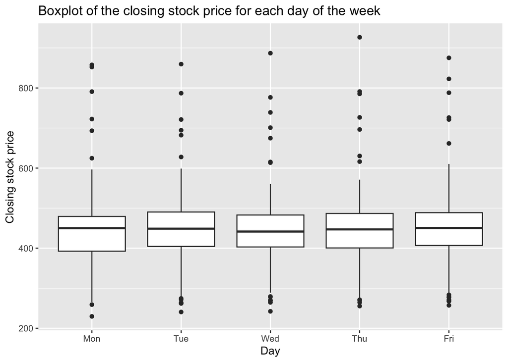

```r
NVIDIA <- NVIDIA %>%
  mutate(Day = wday(Date, label = TRUE))

NVIDIA %>%
  ggplot(mapping = aes(x = Day, y = Close)) +
  geom_boxplot() +
  labs(title = "Boxplot of the closing stock price for each day of the week",
       x = "Day",
       y = "Closing stock price")
```

```r
## Comment: no, there is no day-of-the-week effect as price in every day are almost the same.
```

> 2. 12 Marks
> - There are gaps in the NVIDIA data set due to there being no observations for the weekend. Create a trading day variable using the `row_number` function, and update your `tsibble` such that the index is now the trading day.
> - Fit the following three benchmark forecast models to the closing stock prices for NVIDIA: Average method, naive method, and random-walk with drift method.
> - Forecast 20 trading days ahead and plot your forecasts on the same plot as the closing stock price time series. For your forecasts, only plot the point-forecasts, and not the prediction intervals.
> - Of the three models, which one do you believe produces the worst forecasts? Explain your answer.
> - Of the three models, which one do you believe produces the best forecasts? Explain your answer.

```
## Plot variable not specified, automatically selected `.vars = .mean`
```

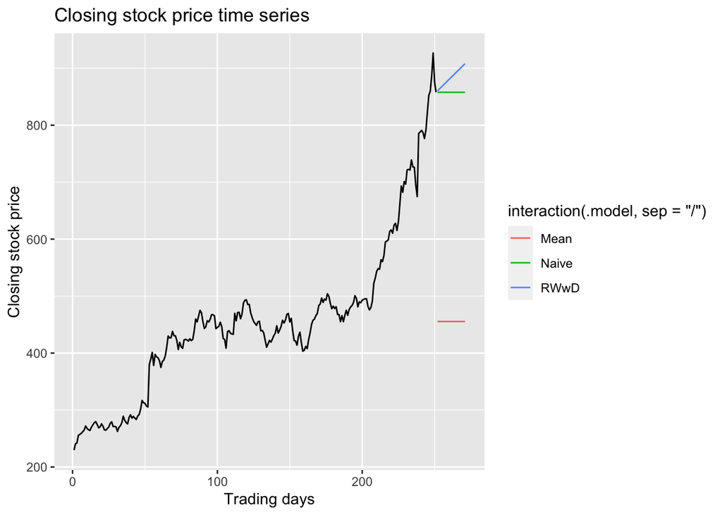

```r
NVIDIA <- NVIDIA %>%
  mutate(Trading_day = row_number()) %>%
  update_tsibble(index = Trading_day, regular = TRUE)

## forecast models
models <- NVIDIA %>%
  model(
    Mean = MEAN(Close),
    Naive = NAIVE(Close),
    RWwD = RW(Close ~ drift())
  )

## Forecast 20 trading days ahead
forecasts <- models %>%
  forecast(h = 20)
point_forecasts <- hilo(forecasts, level = 0)

NVIDIA %>%
  autoplot(Close) +
  autolayer(point_forecasts, series = "Point Forecast") +
  labs(title = "Closing stock price time series",
       x = "Trading days",
       y = "Closing stock price")
```

```r
# The mean method produces the worst forecasts, as it deviates significantly from the current stock price.
# The random-walk with drift method produces the best forecasts, as it simulates the trend of the stock.
```

> Total possible marks for **Problem 2**: 18 Marks

# Problem 3: Trading-day Adjustments

STATS 786 only 10 Marks

In class you learned about calendar adjustments. A similar type of adjustment is trading-day adjustments. For a monthly series, this amounts to dividing the time series by the number of trading days (i.e., weekdays that are not public holidays). A widget business in Auckland is closed on weekends and all public holidays relevant to Auckland. The business measures the amount of revenue made per month, but wants to account for the number of trading days in each month. Find the denominator for a trading-day adjustment for each month of 2024. Print these 12 numbers in a `tibble`.

The following website will be helpful: https://www.govt.nz/browse/work/public-holidays-and-work/public-holidays-and-anniversary-dates/

```r
public_holidays_2024 <- ymd(c("2024-01-01", "2024-01-02", "2024-01-29",
                                  "2024-02-06", "2024-03-29", "2024-04-01",
                                  "2024-04-25", "2024-06-03", "2024-06-28",
                                  "2024-10-28", "2024-12-25", "2024-12-26"))

day_in_month <- days_in_month(ymd(sprintf("2024-%02d-01", 1:12)))

trading_days <- sapply(1:12, function(mon) {
  weekdays <- sum(!weekdays(seq(ymd(paste0("2024-", sprintf("%02d", mon), "-01")),
                                      length.out = day_in_month[mon], by = "day"))
                                      %in% c("Saturday", "Sunday"))
  holidays <- sum(seq(ymd(paste0("2024-", sprintf("%02d", mon), "-01")),
                                      length.out = day_in_month[mon], by = "day")
                                      %in% public_holidays_2024)
  weekdays - holidays
})

months <- c("Jan", "Feb", "Mar", "Apr", "May", "Jun", "Jul", "Aug", "Sep", "Oct", "Nov", "Dece")
tibble <- tibble(Month = months, Trading_days = trading_days)
print(tibble)
```

```
## # A tibble: 12 × 2
##    Month Trading_days
##    <chr>        <int>
##  1 Jan             20
##  2 Feb             20
##  3 Mar             20
##  4 Apr             20
##  5 May             23
##  6 Jun             18
##  7 Jul             23
##  8 Aug             22
##  9 Sep             21
## 10 Oct             22
## 11 Nov             21
## 12 Dece            20
```

> Total possible marks for **Problem 3**: 10 Marks for 786

> Total possible marks for **Assignment 2**: 45 Marks for 326 55 Marks for 786